# Puerto Rico 2019 Soil and Root Analyses by Depth

## ANOVA

```
##                Df Sum Sq Mean Sq F value   Pr(>F)
## Site            3 1.1170  0.3723   8.290 0.000169 ***
## SoilDepth       5 0.1614  0.0323   0.719 0.612821
## Site:SoilDepth 15 0.7333  0.0489   1.088 0.393261
## Residuals      45 2.0213  0.0449
## ---
## Signif. codes:  0 '***' 0.001 '**' 0.01 '*' 0.05 '.' 0.1 ' ' 1
## 3 observations deleted due to missingness
```

# Organic P

Unlike resin P, there are stark differences in organic phosphorus content among the sites (p < 0.001) and depths (p < 0.01). In particular, both El Verde sites have significantly higher concentrations than in the Icacos sites. There was no significant interaction between site and depth in determining organic phosphorus, and the boxplot suggests that organic phosphorus tends to decrease until 25-30 cm before increasing slightly.

## Summary Statistics

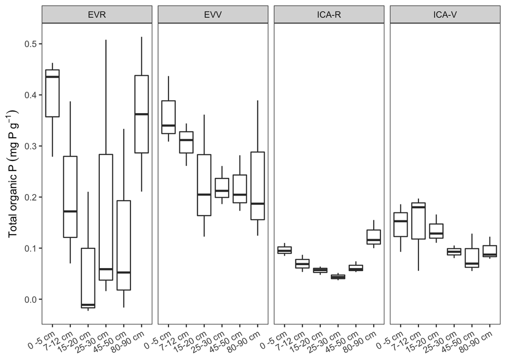

| Site | Depth | n | mean | sd | se |
| --- | --- | --- | --- | --- | --- |
| EVR | 0 -5 cm | 3 | 0.39233333 | 0.099101076 | 0.057216033 |
| EVR | 15-20 cm | 3 | 0.05886667 | 0.131275525 | 0.075791959 |
| EVR | 25-30 cm | 3 | 0.19423333 | 0.272575207 | 0.157371369 |
| EVR | 45-50 cm | 3 | 0.12316667 | 0.185355262 | 0.107014911 |
| EVR | 7-12 cm | 3 | 0.20980000 | 0.162009660 | 0.093536321 |
| EVR | 80-90 cm | 3 | 0.36220000 | 0.214253355 | 0.151500000 |
| EVV | 0 -5 cm | 3 | 0.36183333 | 0.066878572 | 0.038612361 |
| EVV | 15-20 cm | 3 | 0.22956667 | 0.121360386 | 0.070067452 |
| EVV | 25-30 cm | 3 | 0.21976667 | 0.037821995 | 0.021836539 |
| EVV | 45-50 cm | 3 | 0.21980000 | 0.055969992 | 0.032314290 |

[output cut: 14 more lines]

## ANOVA

```
##             Df Sum Sq Mean Sq F value  Pr(>F)
## Site         3  11798    3933  18.153 5.2e-08 ***
## Depth        5   4565     913   4.214 0.00296 **
## Site:Depth  15   4335     289   1.334 0.21990
## Residuals   48  10399     217
## ---
## Signif. codes:  0 '***' 0.001 '**' 0.01 '*' 0.05 '.' 0.1 ' ' 1
```

# Correlations

## Resin P x Soil Phosphatase

The relationship between resin P and soil phosphatase depends on site and depth. As depth increases, the separation among sites diminishes until after 27-32 cm where there is no differenc among sites in soil phosphtase and resin P availability. In general, the Icacos sites tend to have lower soil phosphatase and resin P availability, within each depth. Given similar levels of phosphorus, El Verde sites consistently have higher soil phosphatase activity.

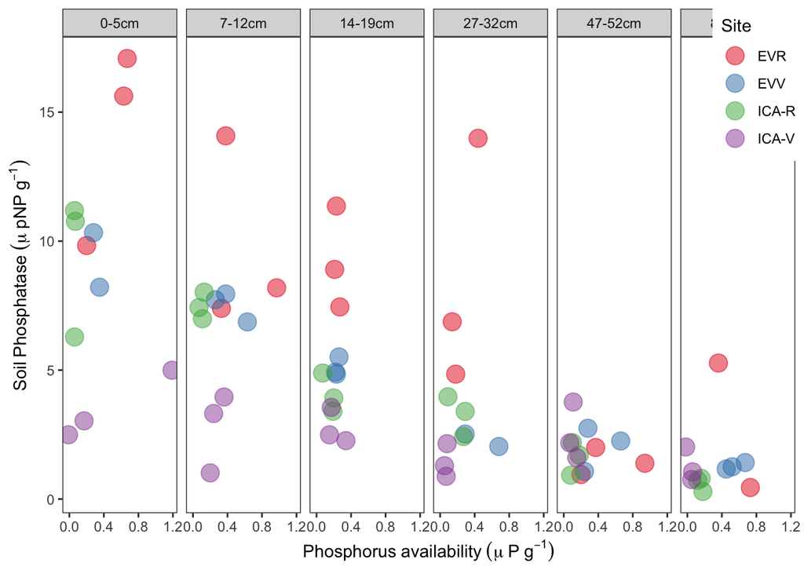

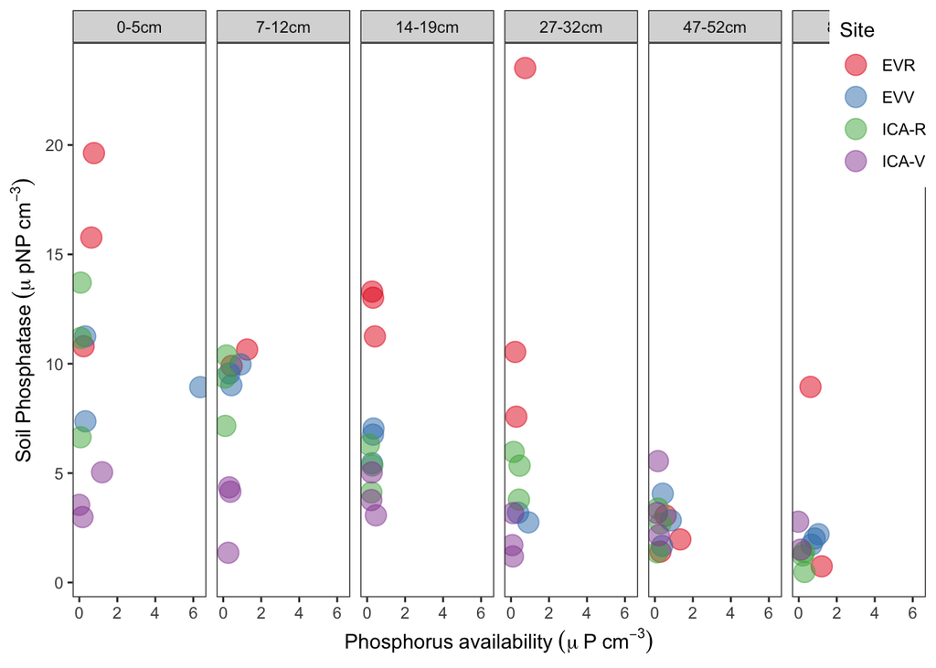

## Organic P x Resin P

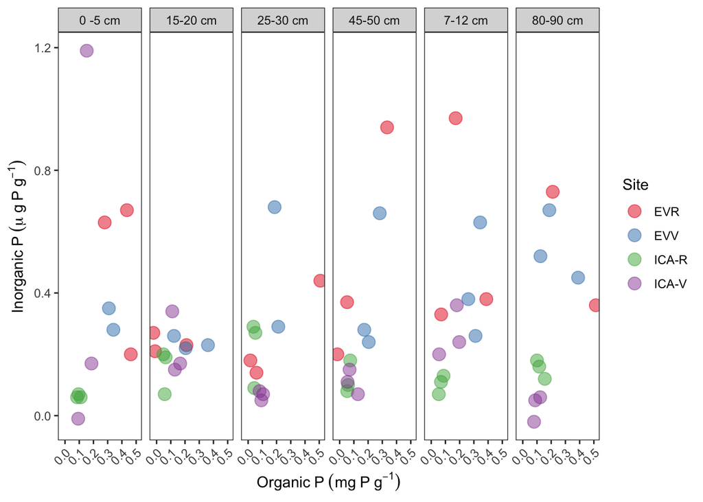